# Module 4: Persistent Homology and Persistence Diagrams

## Introduction

### Essential Concepts

**Topological Data Analysis (TDA)** is a framework for extracting meaningful shape information from data. Unlike traditional statistical methods that focus on distances and distributions, TDA reveals the *topological structure* underlying complex datasets.

#### Key Ideas:

- **Topological Data Analysis (TDA)**: A methodology for analyzing the shape of data using tools from algebraic topology
- **Point cloud data**: A collection of points in some metric space (e.g., $\mathbb{R}^n$), often obtained from:
  - Sensor measurements
  - High-dimensional data embeddings
  - Sampling from manifolds
  - Scientific observations

**Central Question**: How do we extract topological features (connected components, loops, voids) from discrete point clouds?

### Example: Point Cloud Data

Let's generate a simple point cloud sampled from a circle with some noise.

```python
# Import necessary libraries
import numpy as np
import matplotlib.pyplot as plt
from matplotlib.patches import Circle
from scipy.spatial.distance import cdist

# Set random seed for reproducibility
np.random.seed(42)
```

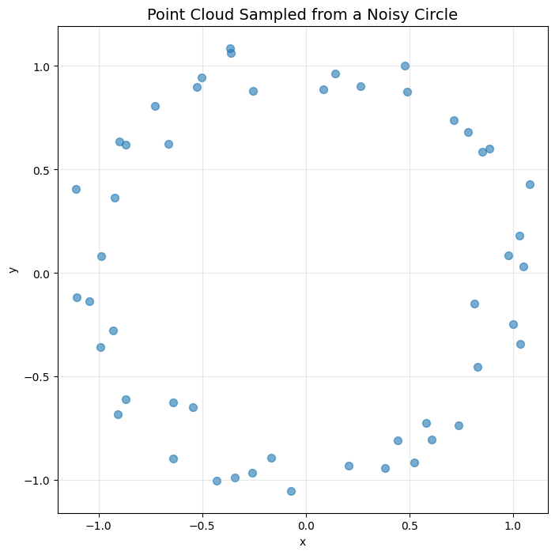

```
Generated 50 points in 2D space
```

```python
# Generate points sampled from a noisy circle
n_points = 50
theta = np.linspace(0, 2*np.pi, n_points, endpoint=False)
radius = 1.0
noise_level = 0.1

# Add noise to the circle
x = radius * np.cos(theta) + np.random.normal(0, noise_level, n_points)
y = radius * np.sin(theta) + np.random.normal(0, noise_level, n_points)

points = np.column_stack([x, y])

# Visualize the point cloud
plt.figure(figsize=(8, 8))
plt.scatter(x, y, s=50, alpha=0.6)
plt.axis('equal')
plt.title('Point Cloud Sampled from a Noisy Circle', fontsize=14)
plt.xlabel('x')
plt.ylabel('y')
plt.grid(True, alpha=0.3)
plt.show()

print(f"Generated {n_points} points in 2D space")
```

## 1. Filtrations (Core Idea)

### Definition

A **filtration** is a nested sequence of topological spaces:

$$ \emptyset = X_0 \subseteq X_1 \subseteq X_2 \subseteq \cdots \subseteq X_n $$

Each space $X_i$ is indexed by a **scale parameter** (often denoted $\epsilon$ or $r$) that controls the granularity at which we examine the shape of the data.

### Why Filtrations?

- Point clouds themselves have trivial topology (just discrete points)
- We need to "thicken" the points to reveal structure
- Different scales reveal different features
- Filtrations provide a systematic way to explore all scales

### Most Common Filtrations

#### 1. Vietoris–Rips Filtration

**Definition**: At scale $r$, connect points $p_i$ and $p_j$ with an edge if $d(p_i, p_j) \leq r$. Add higher-dimensional simplices for all cliques.

- **Pros**: Easy to compute, only requires pairwise distances
- **Cons**: May include simplices that don't correspond to actual geometric balls
- **Most widely used** in practice

**Mathematical notation**: $$ \text{Rips}_r(X) = \{\sigma \subseteq X : d(p_i, p_j) \leq r \text{ for all } p_i, p_j \in \sigma\} $$

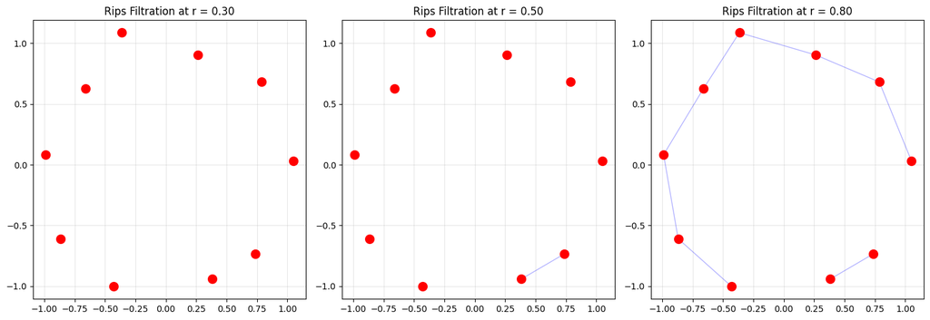

```python
# Visualize Vietoris-Rips filtration at different scales
def plot_rips_filtration(points, radii):
    fig, axes = plt.subplots(1, len(radii), figsize=(5*len(radii), 5))
    if len(radii) == 1:
        axes = [axes]

    for idx, r in enumerate(radii):
        ax = axes[idx]

        # Plot points
        ax.scatter(points[:, 0], points[:, 1], s=100, c='red', zorder=3)

        # Plot edges
        distances = cdist(points, points)
        for i in range(len(points)):
            for j in range(i+1, len(points)):
                if distances[i, j] <= r:
                    ax.plot([points[i, 0], points[j, 0]],
                           [points[i, 1], points[j, 1]],
                           'b-', alpha=0.3, linewidth=1)

        ax.set_aspect('equal')
        ax.set_title(f'Rips Filtration at r = {r:.2f}', fontsize=12)
        ax.grid(True, alpha=0.3)

    plt.tight_layout()
    plt.show()

# Use a smaller subset for clearer visualization
sample_points = points[::5]  # Take every 5th point
radii = [0.3, 0.5, 0.8]
plot_rips_filtration(sample_points, radii)
```

#### 2. Čech Filtration

**Definition**: At scale $r$, a simplex is included if the intersection of balls of radius $r$ centered at its vertices is non-empty.

$$ \text{Čech}_r(X) = \left\{\sigma \subseteq X : \bigcap_{p \in \sigma} B(p, r) \neq \emptyset\right\} $$

- **Pros**: Theoretically correct (captures true nerve of covering)
- **Cons**: Computationally expensive (requires checking higher-order intersections)
- Used when theoretical guarantees are essential

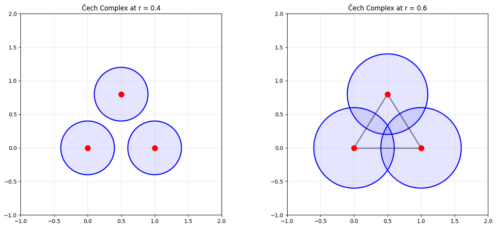

```python
# Visualize Čech filtration concept with ball intersections
def plot_cech_concept():
    fig, axes = plt.subplots(1, 2, figsize=(14, 6))

    # Example points
    pts = np.array([[0, 0], [1, 0], [0.5, 0.8]])

    for idx, r in enumerate([0.4, 0.6]):
        ax = axes[idx]

        # Draw circles
        for i, pt in enumerate(pts):
            circle = Circle(pt, r, fill=False, edgecolor='blue', linewidth=2)
            ax.add_patch(circle)
            circle_fill = Circle(pt, r, alpha=0.1, facecolor='blue')
            ax.add_patch(circle_fill)
            ax.scatter(pt[0], pt[1], s=100, c='red', zorder=3)

        # Draw edges if balls intersect
        for i in range(len(pts)):
            for j in range(i+1, len(pts)):
                if np.linalg.norm(pts[i] - pts[j]) <= 2*r:
                    ax.plot([pts[i, 0], pts[j, 0]],
                           [pts[i, 1], pts[j, 1]],
                           'k-', linewidth=2, alpha=0.5)

        ax.set_xlim(-1, 2)
        ax.set_ylim(-1, 2)
        ax.set_aspect('equal')
        ax.set_title(f'Čech Complex at r = {r:.1f}', fontsize=12)
        ax.grid(True, alpha=0.3)

    plt.tight_layout()
    plt.show()

plot_cech_concept()
```

#### 3. Alpha Filtration

**Definition**: Based on the Delaunay triangulation and Voronoi diagram. A simplex is included at scale $r$ if there exists a ball of radius $r$ that passes through its vertices and contains no other points.

- **Pros**: Efficient in low dimensions (2D, 3D)
- **Cons**: Scales poorly to high dimensions
- Provides a subset of Čech complex with same homology

#### 4. Sublevel-Set Filtration

**Definition**: Given a function $f: X \to \mathbb{R}$, the sublevel set at height $a$ is:

$$ X_a = \{x \in X : f(x) \leq a\} $$

- **Use cases**: Analyzing scalar fields, images, height functions
- Common in applications involving functions on manifolds
- Example: elevation data, density functions, image pixel intensities

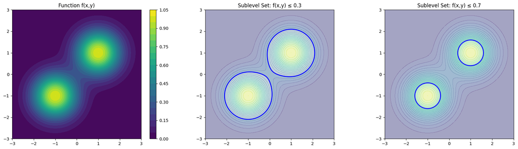

```python
# Visualize sublevel-set filtration on a 2D function
def plot_sublevel_filtration():
    # Create a 2D function (e.g., sum of Gaussians)
    x = np.linspace(-3, 3, 100)
    y = np.linspace(-3, 3, 100)
    X, Y = np.meshgrid(x, y)

    # Function: two Gaussian peaks
    Z = (np.exp(-((X-1)**2 + (Y-1)**2)) +
         np.exp(-((X+1)**2 + (Y+1)**2)))

    fig, axes = plt.subplots(1, 3, figsize=(18, 5))

    # Original function
    im = axes[0].contourf(X, Y, Z, levels=20, cmap='viridis')
    axes[0].set_title('Function f(x,y)', fontsize=12)
    axes[0].set_aspect('equal')
    plt.colorbar(im, ax=axes[0])

    # Sublevel sets at different heights
    for idx, threshold in enumerate([0.3, 0.7]):
        axes[idx+1].contourf(X, Y, Z, levels=[0, threshold], colors=['lightblue'], alpha=0.6)
        axes[idx+1].contour(X, Y, Z, levels=[threshold], colors='blue', linewidths=2)
        axes[idx+1].contourf(X, Y, Z, levels=20, cmap='viridis', alpha=0.3)
        axes[idx+1].set_title(f'Sublevel Set: f(x,y) ≤ {threshold}', fontsize=12)
        axes[idx+1].set_aspect('equal')

    plt.tight_layout()
    plt.show()

plot_sublevel_filtration()
```

### Comparison of Filtrations

| Filtration | Computational Cost | Theoretical Accuracy | Typical Use Case |
| --- | --- | --- | --- |
| Vietoris–Rips | Low | Approximation | General point clouds |
| Čech | High | Exact (nerve theorem) | Theoretical analysis |
| Alpha | Medium (low dim) | Exact (in low dim) | 2D/3D geometric data |
| Sublevel-set | Depends on domain | Exact | Scalar fields, images |

## 2. Topological Features Across Scales

### Birth and Death of Features

As we increase the scale parameter in a filtration, topological features appear and disappear:

- **Birth**: The scale at which a feature first appears
- **Death**: The scale at which the feature is filled, merged, or destroyed

### Types of Features

Persistent homology tracks features in different dimensions:

#### 0-Dimensional Features: Connected Components

- **Birth**: A component is born when a point is added
- **Death**: A component dies when it merges with an older component
- Tracks connectivity of the space

$$H_0 \text{ counts connected components}$$

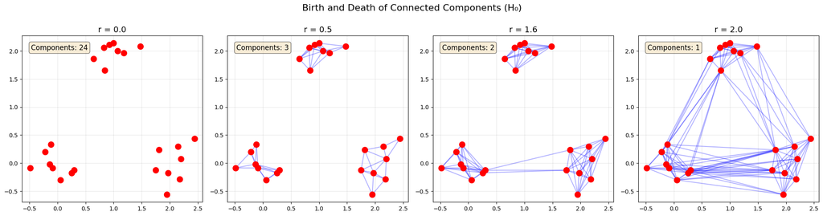

```python
# Visualize birth and death of connected components
def visualize_components():
    # Create 3 clusters of points
    np.random.seed(123)
    cluster1 = np.random.randn(8, 2) * 0.2 + np.array([0, 0])
    cluster2 = np.random.randn(8, 2) * 0.2 + np.array([2, 0])
    cluster3 = np.random.randn(8, 2) * 0.2 + np.array([1, 2])
    points = np.vstack([cluster1, cluster2, cluster3])

    fig, axes = plt.subplots(1, 4, figsize=(20, 5))
    radii = [0.0, 0.5, 1.6, 2]
    component_counts = []

    for idx, r in enumerate(radii):
        ax = axes[idx]
        ax.scatter(points[:, 0], points[:, 1], s=100, c='red', zorder=3)

        if r > 0:
            distances = cdist(points, points)
            for i in range(len(points)):
                for j in range(i+1, len(points)):
                    if distances[i, j] <= r:
                        ax.plot([points[i, 0], points[j, 0]],
                               [points[i, 1], points[j, 1]],
                               'b-', alpha=0.3, linewidth=1.5)

        ax.set_aspect('equal')
        ax.set_title(f'r = {r:.1f}', fontsize=14)
        ax.grid(True, alpha=0.3)

        # Count connected components (simplified - actual computation requires Union-Find)
        if r == 0.0:
            n_components = len(points)
        elif r == 0.5:
            n_components = 3
        elif r == 1.6:
            n_components = 2
        else:
            n_components = 1

        ax.text(0.05, 0.95, f'Components: {n_components}',
               transform=ax.transAxes, fontsize=12,
               verticalalignment='top',
               bbox=dict(boxstyle='round', facecolor='wheat', alpha=0.5))

    plt.suptitle('Birth and Death of Connected Components (H₀)', fontsize=16, y=1.02)
    plt.tight_layout()
    plt.show()

visualize_components()
```

#### 1-Dimensional Features: Loops and Holes

- **Birth**: A loop is born when a cycle is formed
- **Death**: A loop dies when it is filled by a 2-dimensional simplex
- Captures circular structure in data

$$H_1 \text{ counts loops/holes}$$

**Example**: Points sampled from a circle create a 1-dimensional hole

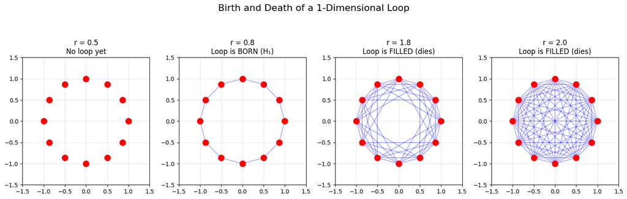

```python
# Visualize birth and death of a loop
def visualize_loop():
    # Generate circle points
    n = 12
    theta = np.linspace(0, 2*np.pi, n, endpoint=False)
    circle_points = np.column_stack([np.cos(theta), np.sin(theta)])

    fig, axes = plt.subplots(1, 4, figsize=(15, 5))
    radii = [0.5, 0.8, 1.8, 2]

    for idx, r in enumerate(radii):
        ax = axes[idx]
        ax.scatter(circle_points[:, 0], circle_points[:, 1], s=100, c='red', zorder=3)

        distances = cdist(circle_points, circle_points)
        for i in range(len(circle_points)):
            for j in range(i+1, len(circle_points)):
                if distances[i, j] <= r:
                    ax.plot([circle_points[i, 0], circle_points[j, 0]],
                           [circle_points[i, 1], circle_points[j, 1]],
                           'b-', alpha=0.3, linewidth=1.5)

        ax.set_xlim(-1.5, 1.5)
        ax.set_ylim(-1.5, 1.5)
        ax.set_aspect('equal')
        ax.grid(True, alpha=0.3)

        if idx == 0:
            title = f'r = {r:.1f}\nNo loop yet'
        elif idx == 1:
            title = f'r = {r:.1f}\nLoop is BORN (H₁)'
        elif idx == 1.8:
            title = f'r = {r:.1f}\nLoop is still alive (H₁)'
        else:
            title = f'r = {r:.1f}\nLoop is FILLED (dies)'

        ax.set_title(title, fontsize=12)

    plt.suptitle('Birth and Death of a 1-Dimensional Loop', fontsize=16, y=1.02)
    plt.tight_layout()
    plt.show()

visualize_loop()
```

#### 2-Dimensional Features: Voids

- **Birth**: A void is born when a hollow 3D cavity is formed
- **Death**: A void dies when it is filled by a 3-dimensional simplex
- Captures volumetric structure

$$H_2 \text{ counts voids/cavities}$$

**Example**: Points sampled from the surface of a sphere create a 2-dimensional void

### Key Insight

By tracking when features are **born** and when they **die** across the filtration, we obtain a multiscale signature of the topological structure of our data. Features that persist for a long time (long lifespan) are typically considered **signal**, while short-lived features are often treated as **noise**.

This leads naturally to the concept of **persistence**, which we'll explore in the next sections.

#### Signal vs. Noise Heuristic

A fundamental heuristic (widely used in practice):

- **Long-lived features** (large persistence) → meaningful structure, signal
- **Short-lived features** (small persistence) → noise, artifacts

**Example**: Points sampled from a noisy circle create a prominent 1-dimensional loop that persists across many scales (signal), while small noise-induced loops appear and disappear quickly (noise).

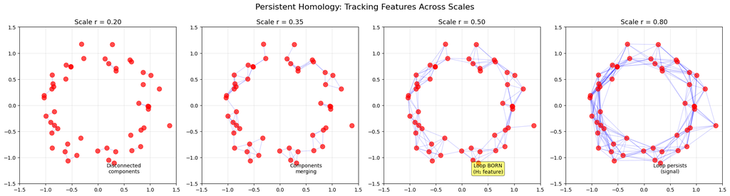

```
Key observation: The main loop (H₁) persists from r≈0.5 to large r → SIGNAL
Small loops appear and disappear quickly → NOISE
```

```python
# Example: Generate noisy circle data
n_points = 50
theta = np.linspace(0, 2*np.pi, n_points, endpoint=False)
radius = 1.0
noise_level = 0.15

x = radius * np.cos(theta) + np.random.normal(0, noise_level, n_points)
y = radius * np.sin(theta) + np.random.normal(0, noise_level, n_points)
circle_points = np.column_stack([x, y])

# Visualize the evolution of topology
fig, axes = plt.subplots(1, 4, figsize=(20, 5))
radii = [0.2, 0.35, 0.5, 0.8]

for idx, r in enumerate(radii):
    ax = axes[idx]
    ax.scatter(x, y, s=80, c='red', zorder=3, alpha=0.7)

    # Draw edges for Rips complex
    distances = cdist(circle_points, circle_points)
    for i in range(len(circle_points)):
        for j in range(i+1, len(circle_points)):
            if distances[i, j] <= r:
                ax.plot([circle_points[i, 0], circle_points[j, 0]],
                       [circle_points[i, 1], circle_points[j, 1]],
                       'b-', alpha=0.2, linewidth=1)

    ax.set_aspect('equal')
    ax.set_title(f'Scale r = {r:.2f}', fontsize=13)
    ax.grid(True, alpha=0.3)
    ax.set_xlim(-1.5, 1.5)
    ax.set_ylim(-1.5, 1.5)

    # Add annotation
    if idx == 0:
        ax.text(0.5, -1.3, 'Disconnected\ncomponents', ha='center', fontsize=10)
    elif idx == 1:
        ax.text(0.5, -1.3, 'Components\nmerging', ha='center', fontsize=10)
    elif idx == 2:
        ax.text(0.5, -1.3, 'Loop BORN\n(H₁ feature)', ha='center', fontsize=10,
               bbox=dict(boxstyle='round', facecolor='yellow', alpha=0.5))
    else:
        ax.text(0.5, -1.3, 'Loop persists\n(signal)', ha='center', fontsize=10)

plt.suptitle('Persistent Homology: Tracking Features Across Scales', fontsize=16, y=1.02)
plt.tight_layout()
plt.show()

print("Key observation: The main loop (H₁) persists from r≈0.5 to large r → SIGNAL")
print("Small loops appear and disappear quickly → NOISE")
```

## 3. Persistent Homology

### Formal Definition: Persistence Module

Given a filtration: $$ \emptyset = X_0 \subseteq X_1 \subseteq X_2 \subseteq \cdots \subseteq X_n $$

The **persistence module** is a sequence of homology groups with homomorphisms: $$ H_k(X_0) \xrightarrow{f_0} H_k(X_1) \xrightarrow{f_1} H_k(X_2) \xrightarrow{f_2} \cdots \xrightarrow{f_{n-1}} H_k(X_n) $$

where:

- $H_k(X_i)$ is the $k$-th homology group of space $X_i$ (it can be taken with some coefficent group)
- $f_i: H_k(X_i) \to H_k(X_{i+1})$ are homomorphisms induced by inclusion $X_i \subseteq X_{i+1}$

### Structure Theorem

By the **Structure Theorem for persistence modules**, any persistence module can be decomposed as: $$ M \cong \bigoplus_i I_{[b_i, d_i)} $$

where $I_{[b, d)}$ is an interval module (non-zero on $[b, d)$, zero outside).

Each interval $[b_i, d_i)$ corresponds to a topological feature born at $b_i$ and dying at $d_i$.

## 4. Persistence Diagrams & Barcodes

The results of persistent homology are visualized using two equivalent representations:

### 4.1 Barcodes

A **barcode** is a collection of intervals $[birth, death)$ visualized as horizontal bars.

#### Structure:

- Each horizontal bar represents one topological feature
- Left endpoint = birth time
- Right endpoint = death time
- Length of bar = persistence (death - birth)

#### Interpretation:

- **Long bars** → significant features (signal)
- **Short bars** → insignificant features (noise)

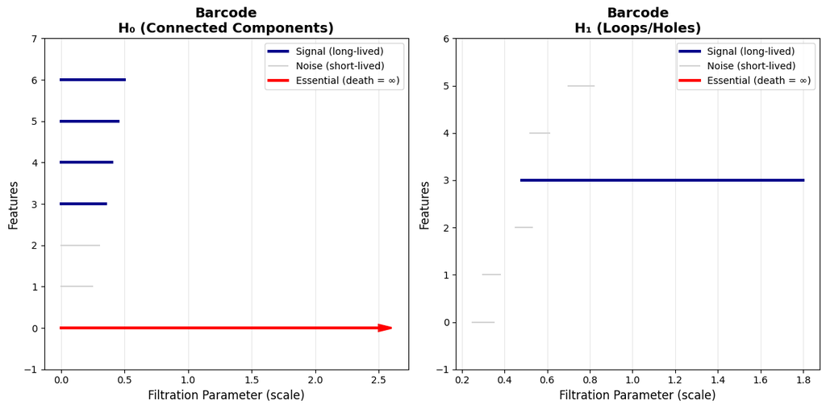

```python
# Example: Create a barcode visualization
def plot_barcode(ax, intervals, title, dimension):
    # Sort by birth time
    intervals_sorted = sorted(intervals, key=lambda x: x[0])

    for idx, (birth, death) in enumerate(intervals_sorted):
        if death == np.inf:
            # Essential feature - draw arrow
            ax.arrow(birth, idx, 2.5, 0, head_width=0.15, head_length=0.1,
                    fc='red', ec='red', linewidth=2)
            ax.plot([birth, birth + 2.5], [idx, idx], 'r-', linewidth=3)
        else:
            # Regular feature
            persistence = death - birth
            color = 'darkblue' if persistence > 0.3 else 'lightgray'
            linewidth = 3 if persistence > 0.3 else 1.5
            ax.plot([birth, death], [idx, idx], color=color, linewidth=linewidth)

    ax.set_xlabel('Filtration Parameter (scale)', fontsize=12)
    ax.set_ylabel('Features', fontsize=12)
    ax.set_title(f'{title}\n{dimension}', fontsize=14, fontweight='bold')
    ax.grid(True, alpha=0.3, axis='x')
    ax.set_ylim(-1, len(intervals))

    # Add legend
    from matplotlib.lines import Line2D
    legend_elements = [
        Line2D([0], [0], color='darkblue', linewidth=3, label='Signal (long-lived)'),
        Line2D([0], [0], color='lightgray', linewidth=1.5, label='Noise (short-lived)'),
        Line2D([0], [0], color='red', linewidth=3, label='Essential (death = ∞)')
    ]
    ax.legend(handles=legend_elements, loc='upper right')

# Example data: H₀ (connected components)
h0_intervals = [
    (0.0, np.inf),  # Essential: main component
    (0.0, 0.25),    # Components merge
    (0.0, 0.30),
    (0.0, 0.35),
    (0.0, 0.40),
    (0.0, 0.45),
    (0.0, 0.50),
]

# Example data: H₁ (loops)
h1_intervals = [
    (0.48, 1.80),   # Main loop (SIGNAL)
    (0.25, 0.35),   # Noise
    (0.30, 0.38),   # Noise
    (0.52, 0.61),   # Noise
    (0.45, 0.53),   # Noise
    (0.70, 0.82),   # Small loop
]

# Create subplots with two columns
fig, axes = plt.subplots(1, 2, figsize=(12, 6))

# Plot H₀ barcode on the first axis (left)
plot_barcode(axes[0], h0_intervals, 'Barcode', 'H₀ (Connected Components)')

# Plot H₁ barcode on the second axis (right)
plot_barcode(axes[1], h1_intervals, 'Barcode', 'H₁ (Loops/Holes)')

# Adjust layout for better spacing
plt.tight_layout()
plt.show()
```

### 4.2 Persistence Diagrams

A **persistence diagram** is a multiset of points $(b, d)$ in the plane.

#### Structure:

- Each point $(b, d)$ represents a feature born at time $b$ and dying at time $d$
- The $x$-axis represents birth times
- The $y$-axis represents death times
- All points lie above or on the diagonal $y = x$ (since death ≥ birth)

**The Diagonal**: The line $y = x$

- Represents features with **zero persistence** (birth = death)
- Points near the diagonal → noise
- Distance from diagonal = persistence

**Essential Features**: Points with $death = \infty$

- Features that never die in the filtration
- Often represent true topological structure

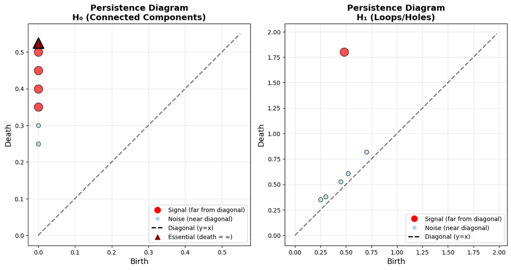

```python
# Create persistence diagram visualization
def plot_persistence_diagram(ax, points, title, dimension):
    # Separate finite and infinite death times
    finite_points = [(b, d) for b, d in points if d != np.inf]
    essential_points = [(b, d) for b, d in points if d == np.inf]

    # Plot diagonal
    max_val = max([d for b, d in finite_points] + [b for b, d in finite_points]) if finite_points else 2.0
    diag_line = np.linspace(0, max_val * 1.1, 100)
    ax.plot(diag_line, diag_line, 'k--', linewidth=2, label='Diagonal (y=x)', alpha=0.5)

    # Plot finite points
    if finite_points:
        births = [b for b, d in finite_points]
        deaths = [d for b, d in finite_points]
        persistences = [d - b for b, d in finite_points]

        # Color by persistence
        colors = ['red' if p > 0.3 else 'lightblue' for p in persistences]
        sizes = [200 if p > 0.3 else 50 for p in persistences]

        for b, d, c, s in zip(births, deaths, colors, sizes):
            ax.scatter(b, d, c=c, s=s, alpha=0.7, edgecolors='black', linewidth=1)

    # Plot essential points (at top of diagram)
    if essential_points:
        essential_births = [b for b, d in essential_points]
        essential_y = [max_val * 1.05] * len(essential_births)  # Place near top
        ax.scatter(essential_births, essential_y, c='darkred', s=300,
                  marker='^', label='Essential (death = ∞)',
                  edgecolors='black', linewidth=2)

    ax.set_xlabel('Birth', fontsize=13)
    ax.set_ylabel('Death', fontsize=13)
    ax.set_title(f'{title}\n{dimension}', fontsize=14, fontweight='bold')
    ax.grid(True, alpha=0.3)
    ax.set_aspect('equal')

    # Add legend
    from matplotlib.lines import Line2D
    legend_elements = [
        Line2D([0], [0], marker='o', color='w', markerfacecolor='red',
               markersize=12, label='Signal (far from diagonal)'),
        Line2D([0], [0], marker='o', color='w', markerfacecolor='lightblue',
               markersize=8, label='Noise (near diagonal)'),
        Line2D([0], [0], color='k', linestyle='--', linewidth=2, label='Diagonal (y=x)')
    ]
    if essential_points:
        legend_elements.append(
            Line2D([0], [0], marker='^', color='w', markerfacecolor='darkred',
                   markersize=12, label='Essential (death = ∞)')
        )
    ax.legend(handles=legend_elements, loc='lower right', fontsize=10)

# Create subplots with two columns
fig, axes = plt.subplots(1, 2, figsize=(12, 6))

# Plot H₀ persistence diagram on the first axis (left)
plot_persistence_diagram(axes[0], h0_intervals, 'Persistence Diagram', 'H₀ (Connected Components)')

# Plot H₁ persistence diagram on the second axis (right)
plot_persistence_diagram(axes[1], h1_intervals, 'Persistence Diagram', 'H₁ (Loops/Holes)')

# Adjust layout for better spacing
plt.tight_layout()
plt.show()
```

### Interpreting Persistence Diagrams

**Distance from diagonal** = persistence = death - birth

For a point $(b, d)$:

- Perpendicular distance to diagonal: $\frac{d - b}{\sqrt{2}}$
- Larger distance → more significant feature

**Key observations**:

1. Points clustered near diagonal → noise
2. Points far from diagonal → topological signal
3. Essential features (triangles at top) → persistent structure
4. Empty regions → no features with those birth/death times

### Equivalence of Representations

Barcodes and persistence diagrams contain the same information:

- **Barcode** $[b, d)$ ↔ **Diagram point** $(b, d)$
- Choice depends on application
- **Barcodes**: Better for visualizing temporal evolution
- **Diagrams**: Better for computing distances between datasets

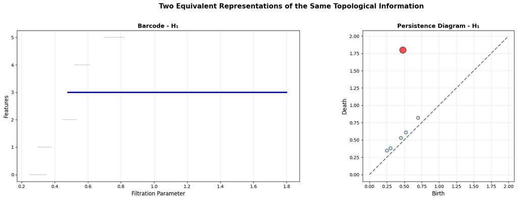

```python
# Side-by-side comparison
def compare_representations(intervals, dimension):
    fig = plt.figure(figsize=(18, 6))

    # Barcode (left)
    ax1 = plt.subplot(1, 2, 1)
    intervals_sorted = sorted([i for i in intervals if i[1] != np.inf], key=lambda x: x[0])

    for idx, (birth, death) in enumerate(intervals_sorted):
        persistence = death - birth
        color = 'darkblue' if persistence > 0.3 else 'lightgray'
        linewidth = 3 if persistence > 0.3 else 1.5
        ax1.plot([birth, death], [idx, idx], color=color, linewidth=linewidth)

    ax1.set_xlabel('Filtration Parameter', fontsize=12)
    ax1.set_ylabel('Features', fontsize=12)
    ax1.set_title(f'Barcode - {dimension}', fontsize=13, fontweight='bold')
    ax1.grid(True, alpha=0.3, axis='x')

    # Persistence diagram (right)
    ax2 = plt.subplot(1, 2, 2)

    finite_points = [(b, d) for b, d in intervals if d != np.inf]
    if finite_points:
        births = [b for b, d in finite_points]
        deaths = [d for b, d in finite_points]
        persistences = [d - b for b, d in finite_points]

        max_val = max(deaths + births)
        diag_line = np.linspace(0, max_val * 1.1, 100)
        ax2.plot(diag_line, diag_line, 'k--', linewidth=2, alpha=0.5)

        colors = ['red' if p > 0.3 else 'lightblue' for p in persistences]
        sizes = [200 if p > 0.3 else 50 for p in persistences]

        for b, d, c, s in zip(births, deaths, colors, sizes):
            ax2.scatter(b, d, c=c, s=s, alpha=0.7, edgecolors='black', linewidth=1)

    ax2.set_xlabel('Birth', fontsize=12)
    ax2.set_ylabel('Death', fontsize=12)
    ax2.set_title(f'Persistence Diagram - {dimension}', fontsize=13, fontweight='bold')
    ax2.grid(True, alpha=0.3)
    ax2.set_aspect('equal')

    plt.suptitle('Two Equivalent Representations of the Same Topological Information',
                fontsize=15, fontweight='bold', y=1.02)
    plt.tight_layout()
    plt.show()

compare_representations(h1_intervals, 'H₁')
```

## 5. Distances & Stability

### 5.1 The Need for Distance Metrics

When working with persistence diagrams, we need ways to:

- **Compare** diagrams from different datasets
- **Quantify** how similar or different two topological signatures are
- **Understand** how noise or perturbations affect our results

### 5.2 Bottleneck Distance

The **bottleneck distance** is the standard metric for comparing persistence diagrams.

#### Definition

Given two persistence diagrams $D_1$ and $D_2$, the bottleneck distance is:

$$d_B(D_1, D_2) = \inf_{\gamma} \sup_{p \in D_1} \|p - \gamma(p)\|_\infty$$

where:

- $\gamma$ ranges over all bijections between $D_1 \cup \Delta$ and $D_2 \cup \Delta$
- $\Delta$ is the diagonal (points with birth = death)
- $\|\cdot\|_\infty$ is the supremum norm: $\|(b_1, d_1) - (b_2, d_2)\|_\infty = \max\{|b_1 - b_2|, |d_1 - d_2|\}$

#### Intuition

The bottleneck distance finds the best matching between points in two diagrams, where:

- Each point in $D_1$ is matched to exactly one point in $D_2$ or to the diagonal
- The distance is determined by the **worst** (maximum) matching cost
- Points can be matched to the diagonal, representing creation or destruction of features

#### Example: Computing Bottleneck Distance

Consider two simple persistence diagrams:

- $D_1 = \{(1, 4), (2, 5)\}$
- $D_2 = \{(1.2, 4.1), (2.1, 4.9)\}$

**Matching 1**: $(1,4) \leftrightarrow (1.2, 4.1)$ and $(2,5) \leftrightarrow (2.1, 4.9)$

$$\text{Cost}_1 = \max\{0.2, 0.1\} = 0.2$$ $$\text{Cost}_2 = \max\{0.1, 0.1\} = 0.1$$ $$d_B = \max\{0.2, 0.1\} = 0.2$$

This would be the optimal matching in this case.

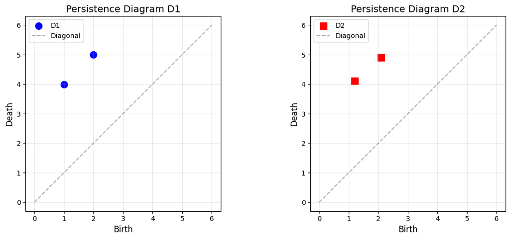

```python
import numpy as np
import matplotlib.pyplot as plt

# Visualize two persistence diagrams
D1 = np.array([[1, 4], [2, 5]])
D2 = np.array([[1.2, 4.1], [2.1, 4.9]])

fig, (ax1, ax2) = plt.subplots(1, 2, figsize=(12, 5))

# Plot D1
ax1.scatter(D1[:, 0], D1[:, 1], s=100, c='blue', marker='o', label='D1')
ax1.plot([0, 6], [0, 6], 'k--', alpha=0.3, label='Diagonal')
ax1.set_xlabel('Birth', fontsize=12)
ax1.set_ylabel('Death', fontsize=12)
ax1.set_title('Persistence Diagram D1', fontsize=14)
ax1.legend()
ax1.grid(True, alpha=0.3)
ax1.set_aspect('equal')

# Plot D2
ax2.scatter(D2[:, 0], D2[:, 1], s=100, c='red', marker='s', label='D2')
ax2.plot([0, 6], [0, 6], 'k--', alpha=0.3, label='Diagonal')
ax2.set_xlabel('Birth', fontsize=12)
ax2.set_ylabel('Death', fontsize=12)
ax2.set_title('Persistence Diagram D2', fontsize=14)
ax2.legend()
ax2.grid(True, alpha=0.3)
ax2.set_aspect('equal')

plt.tight_layout()
plt.show()
```

### 5.3 Wasserstein Distance

The **Wasserstein distance** (also called Earth Mover's Distance) is a generalization of the bottleneck distance.

#### Definition

The $p$-Wasserstein distance between persistence diagrams $D_1$ and $D_2$ is:

$$W_p(D_1, D_2) = \left(\inf_{\gamma} \sum_{p \in D_1} \|p - \gamma(p)\|_\infty^p\right)^{1/p}$$

where $p \geq 1$ and $\gamma$ ranges over all bijections as before.

#### Special Cases

- **$p = 1$**: Total cost of optimal matching
- **$p = 2$**: Commonly used in machine learning applications
- **$p \to \infty$**: Recovers the bottleneck distance

$$d_B(D_1, D_2) = \lim_{p \to \infty} W_p(D_1, D_2)$$

#### Example: Wasserstein vs Bottleneck

Consider:

- $D_1 = \{(1, 3), (2, 4), (3, 5)\}$
- $D_2 = \{(1.1, 3.1), (2.1, 4.1), (3.1, 5.1)\}$

With optimal matching:

**Bottleneck**: $d_B = 0.1$ (maximum individual cost)

**1-Wasserstein**: $W_1 = 0.1 + 0.1 + 0.1 = 0.3$ (sum of costs)

**2-Wasserstein**: $W_2 = \sqrt{0.1^2 + 0.1^2 + 0.1^2} = \sqrt{0.03} \approx 0.173$

```python
# Demonstrate difference between Bottleneck and Wasserstein
def compute_wasserstein_p(D1, D2, p):
    """Simple computation assuming optimal matching is identity"""
    if len(D1) != len(D2):
        raise ValueError("Diagrams must have same size for this example")

    costs = np.max(np.abs(D1 - D2), axis=1)  # L-infinity norm
    if p == np.inf:
        return np.max(costs)
    else:
        return np.power(np.sum(np.power(costs, p)), 1/p)

# Example diagrams
D1 = np.array([[1, 3], [2, 4], [3, 5]])
D2 = np.array([[1.1, 3.1], [2.1, 4.1], [3.1, 5.1]])

print("Distance comparisons:")
print(f"Bottleneck (p=∞): {compute_wasserstein_p(D1, D2, np.inf):.4f}")
print(f"1-Wasserstein:    {compute_wasserstein_p(D1, D2, 1):.4f}")
print(f"2-Wasserstein:    {compute_wasserstein_p(D1, D2, 2):.4f}")
print(f"5-Wasserstein:    {compute_wasserstein_p(D1, D2, 5):.4f}")
```

```
Distance comparisons:
Bottleneck (p=∞): 0.1000
1-Wasserstein:    0.3000
2-Wasserstein:    0.1732
5-Wasserstein:    0.1246
```

### 5.4 Stability Theorem

The **stability theorem** is the key theoretical justification for using persistent homology in data analysis.

#### Statement

Let $f, g: X \to \mathbb{R}$ be two continuous functions on a topological space $X$. Let $D_f$ and $D_g$ be their persistence diagrams obtained from sublevel-sets filtrations given by $f$ and $g$. Then:

$$d_B(D_f, D_g) \leq \|f - g\|_\infty$$

where $\|f - g\|_\infty = \sup_{x \in X} |f(x) - g(x)|$ is the uniform distance between functions.

#### Interpretation

This theorem tells us that:

- **Small perturbations** in the input function lead to **small changes** in the persistence diagram
- The bottleneck distance between diagrams is bounded by the maximum pointwise difference in functions
- Persistent homology is **robust to noise** in the data

#### Practical Implications

1. **Noise tolerance**: If we add noise $\epsilon$ to our data, features in the persistence diagram can move by at most $\epsilon$.
2. **Feature reliability**: Features that persist much longer than the noise level are reliable.
3. **Sampling**: When approximating a continuous space with a finite sample, the persistence diagram changes predictably.

#### Example: Noisy Circle

Consider a circle sampled with noise:

- **Clean circle**: Shows one persistent $H_1$ feature (the loop)
- **Noisy circle**: The main loop persists, but many small features appear and die quickly
- **Stability**: The main feature moves slightly, but remains distinguishable

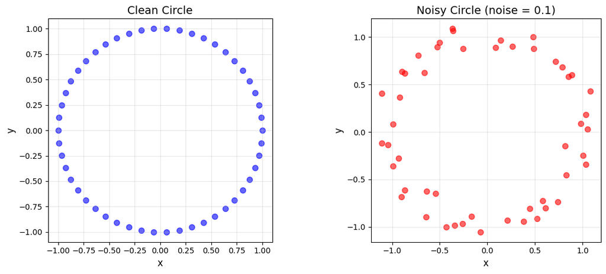

```
Expected behavior:
- Both should show one persistent H1 feature (the loop)
- Noisy version will have many short-lived features
- Main loop feature persists and is stable (moves by ≤ noise level)
```

```python
# Demonstrate stability with noisy data
def generate_circle(n_points, radius=1, noise_level=0):
    """Generate points on a circle with optional noise"""
    theta = np.linspace(0, 2*np.pi, n_points, endpoint=False)
    x = radius * np.cos(theta)
    y = radius * np.sin(theta)

    if noise_level > 0:
        x += np.random.normal(0, noise_level, n_points)
        y += np.random.normal(0, noise_level, n_points)

    return np.column_stack([x, y])

# Generate clean and noisy circles
np.random.seed(42)
circle_clean = generate_circle(50, radius=1, noise_level=0)
circle_noisy = generate_circle(50, radius=1, noise_level=0.1)

fig, (ax1, ax2) = plt.subplots(1, 2, figsize=(12, 5))

# Plot clean circle
ax1.scatter(circle_clean[:, 0], circle_clean[:, 1], s=50, c='blue', alpha=0.6)
ax1.set_xlabel('x', fontsize=12)
ax1.set_ylabel('y', fontsize=12)
ax1.set_title('Clean Circle', fontsize=14)
ax1.set_aspect('equal')
ax1.grid(True, alpha=0.3)

# Plot noisy circle
ax2.scatter(circle_noisy[:, 0], circle_noisy[:, 1], s=50, c='red', alpha=0.6)
ax2.set_xlabel('x', fontsize=12)
ax2.set_ylabel('y', fontsize=12)
ax2.set_title('Noisy Circle (noise = 0.1)', fontsize=14)
ax2.set_aspect('equal')
ax2.grid(True, alpha=0.3)

plt.tight_layout()
plt.show()

print("Expected behavior:")
print("- Both should show one persistent H1 feature (the loop)")
print("- Noisy version will have many short-lived features")
print("- Main loop feature persists and is stable (moves by ≤ noise level)")
```

#### Extended Stability Results

The stability theorem extends to:

- **Wasserstein distances**: Similar bounds hold for $W_p$ distances
- **Different filtrations**: Rips, Čech, alpha complexes all satisfy stability
- **Distance functions**: The distance function $d_A(x) = \inf_{a \in A} d(x, a)$ satisfies stability under Hausdorff perturbations

## 6. Algorithm for Computing Persistent Homology

### 6.1 Matrix Reduction Algorithm

Persistent homology is computed through **matrix reduction** of the boundary operator. The algorithm transforms the boundary matrix into a reduced form that directly reveals birth and death times of homological features.

#### The Boundary Matrix

For a filtered simplicial complex $K_1 \subseteq K_2 \subseteq \cdots \subseteq K_n$, we consider simplices ordered by their filtration time.

The boundary matrix $\partial$ has columns indexed by simplices and rows indexed by their faces, with entry 1 if the row simplex is in the boundary of the column simplex.

For simplicity, all arithmetic is mod 2 (we take coefficients in $\mathbb{Z}_2$).

### Matrix Reduction Algorithm

**Goal:** Reduce the boundary matrix to a form where we can read off birth-death pairs.

**Algorithm (Standard Reduction):**

1. **Order simplices** by filtration value (ties broken arbitrarily)
2. **Initialize:** $D = \partial$ (boundary matrix)
3. **For each column $j$ from left to right:**
   - While column $j$ has the same lowest 1 as a previous column $i$:
     - Add column $i$ to column $j$ (mod 2)
   - Mark the lowest 1 position in column $j$ (if any exists)

**Result:** The reduced matrix $R$ has the property that no two columns have their lowest 1 in the same row.

### Reading Birth-Death Pairs

After reduction:

- **Birth:** A simplex $\sigma$ creates a feature if its column becomes empty (all zeros)
- **Death:** A simplex $\tau$ kills a feature created by $\sigma$ if $\tau$'s column has its lowest 1 in $\sigma$'s row

### Example: Computing $H_0$ and $H_1$ for a Triangle

Consider building a triangle with filtration:

- Time 0: vertices $\{a, b, c\}$
- Time 1: edges $\{ab, bc, ca\}$
- Time 2: triangle $\{abc\}$

**Step 1: List simplices in filtration order**

| Index | Simplex | Dimension | Filtration time |
| --- | --- | --- | --- |
| 0 | $a$ | 0 | 0 |
| 1 | $b$ | 0 | 0 |
| 2 | $c$ | 0 | 0 |
| 3 | $ab$ | 1 | 1 |
| 4 | $bc$ | 1 | 1 |
| 5 | $ca$ | 1 | 1 |
| 6 | $abc$ | 2 | 2 |

**Step 2: Construct boundary matrix**

Columns = simplices, Rows = faces (using mod 2 arithmetic)

$$\partial = \begin{pmatrix} & & & ab & bc & ca & abc \\ a & & & 1 & 0 & 1 & 0 \\ b & & & 1 & 1 & 0 & 0 \\ c & & & 0 & 1 & 1 & 0 \\ ab & & & & & & 1 \\ bc & & & & & & 1 \\ ca & & & & & & 1 \end{pmatrix}$$

The first three columns (vertices) are empty since vertices have no boundary.

**Step 3: Reduce the matrix**

Process columns left to right:

**Step 4: Extract persistence pairs**

**For $H_0$ (connected components):**

- Simplex $a$ (index 0): column empty → **birth at time 0**
- Simplex $b$ (index 1): column empty → **birth at time 0**
- Simplex $c$ (index 2): column empty → **birth at time 0**
- Simplex $ab$ (index 3): lowest 1 at row $b$ → **kills $b$ at time 1**
- Simplex $bc$ (index 4): lowest 1 at row $c$ → **kills $c$ at time 1**

Persistence pairs for $H_0$:

- $(b, ab)$: birth 0, death 1 → **(0, 1)**
- $(c, bc)$: birth 0, death 1 → **(0, 1)**
- $a$ is never killed → **(0, ∞)** (essential feature)

**For $H_1$ (loops):**

**Correct interpretation for $H_1$:**

- When $ca$ is added at time 1, a 1-cycle is created (the loop $ab + bc + ca$)
- This cycle is **born at time 1**
- The 2-simplex $abc$ at time 2 fills this loop → **death at time 2**
- Persistence pair: **(1, 2)** for $H_1$

### Summary of Algorithm

1. **Build boundary matrix** from filtered complex
2. **Reduce matrix** using column operations (mod 2)
3. **Extract pairs:**
   - Empty columns → birth of feature
   - Lowest 1 in row $i$ of column $j$ → simplex $j$ kills feature born at simplex $i$
4. **Persistence diagram:** plot (birth, death) pairs

### 6.2 Computational Complexity

#### Bottlenecks

The complexity of persistent homology computation is dominated by:

1. **Filtration size**: Number of simplices in the complex
2. **Matrix reduction**: Can be $O(n^3)$ in worst case, where $n$ is the number of simplices

#### Rips Complex Growth

For a point cloud with $N$ points, the Vietoris-Rips complex at dimension $d$ can have:

$$\text{Number of simplices} \sim O\left(N^{d+1}\right)$$

This **exponential growth** makes computation expensive for:

- Large point clouds ($N > 1000$)
- High dimensions ($d > 3$)
- Dense point clouds

#### Practical Strategies

- **Subsample** large point clouds
- **Limit** maximum dimension (usually $d \leq 2$ suffices)
- **Bound** filtration parameter (maximum edge length)
- Use **sparse** representations
- Apply **cohomology** algorithms (dual computation)

## 7. Interpretation & Usage

### Signal vs. Noise Separation

**Key Principle:** Persistent features = signal, short-lived features = noise

**Persistence as a Filter:**

- **Long persistence** → topological feature survives across many scales → likely **real structure**
- **Short persistence** → feature appears and disappears quickly → likely **noise**

**Quantitative threshold:** $$\text{Keep feature } (b, d) \text{ if } |d - b| > \tau$$

where $\tau$ is a chosen persistence threshold.

### Topological Features for Data Analysis

**1. Vectorization of Persistence Diagrams**

Since machine learning algorithms typically require fixed-dimensional feature vectors, we convert persistence diagrams:

**A. Persistence Statistics:** $$\text{features} = \{\max(p_i), \text{mean}(p_i), \sum p_i^2, \ldots\}$$ where $p_i = d_i - b_i$ is persistence.

**B. Persistence Images:** Convert diagram to a 2D grid with Gaussian weighting: $$\rho(x,y) = \sum_{(b_i,d_i) \in D} w(d_i - b_i) \cdot \mathcal{N}((x,y) | (b_i, d_i), \Sigma)$$

where $w(p) = p$ weights by persistence.

**C. Persistence Landscapes:** Piecewise linear function capturing diagram structure: $$\lambda_k(t) = k\text{-th largest value of } \{|t - b_i|, |t - d_i|\}$$

**D. Betti Curves:** $$\beta_k(t) = \text{rank}(H_k(K_t))$$ counts features alive at scale $t$.

**2. Feature Extraction Pipeline**

```
Raw Data → Filtration → Persistence Diagram → Vectorization → ML Algorithm
   ↓           ↓              ↓                    ↓              ↓
Points    Simplicial     Birth-Death         Feature Vector   Classification/
          Complex         Pairs               (fixed-dim)      Regression
```

### Practical Use Cases

**Example 1: Texture Classification**

Given images of different materials:

- Compute sublevel set filtration on pixel intensities
- Extract persistence diagrams for $H_0$ and $H_1$
- Features distinguish:
  - $H_0$: blob-like structures (bright regions)
  - $H_1$: holes and voids (dark regions)
- Train classifier on persistence features

**Result:** Topological features capture texture patterns independent of exact pixel positions.

**Example 2: Time Series Analysis**

For a periodic signal (e.g., heartbeat ECG):

1. **Takens embedding:** Convert time series to point cloud $$\mathbf{x}_i = (s_i, s_{i+\tau}, s_{i+2\tau}, \ldots, s_{i+(d-1)\tau})$$
2. **Build Rips complex** on embedded points
3. **Compute persistence:**
   - Periodic signals → prominent $H_1$ feature (closed loop in embedding)
   - Noise → many short-lived features
4. **Detect anomalies:** Changes in $H_1$ persistence indicate irregularities

### Summary: Why Persistent Homology Works

**Theoretical guarantees:**

- **Stability theorem:** Small data perturbations → small diagram changes
- **Completeness:** Captures all homological features across all scales
- **Well-defined metrics:** Bottleneck and Wasserstein distances

**Practical advantages:**

- **Noise filtering:** Persistence distinguishes structure from noise
- **Feature extraction:** Provides interpretable topological descriptors
- **Generalization:** Works across diverse data types and applications
- **Robustness:** Inherently stable to small perturbations

**The persistence paradigm:**

> "Features that persist across scales are more likely to represent genuine structure than noise."

This simple principle, backed by rigorous mathematical theory, makes persistent homology a powerful tool for modern data analysis.

### Comparison: Traditional vs. Topological Features

| Aspect | Traditional Features | Topological Features |
| --- | --- | --- |
| **Invariance** | Often coordinate-dependent | Coordinate-free |
| **Noise** | Sensitive to outliers | Stable by design |
| **Scale** | Single scale or fixed scales | Multi-scale automatically |
| **Interpretation** | Domain-specific | Geometric/topological |
| **Computation** | Often fast | Can be expensive |
| **Applicability** | Dataset-specific | General purpose |

**Best practice:** Combine both types of features for optimal performance!

## Further Reading

**Foundational papers:**

- Edelsbrunner et al. (2002): "Topological Persistence and Simplification"
- Carlsson (2009): "Topology and Data" (survey paper)
- Cohen-Steiner et al. (2007): "Stability of Persistence Diagrams"

# Programming tasks

## Task 1: Persistence Diagrams for Shape Analysis of Point Clouds

Write a Python program that uses persistence diagrams to analyze the shape of point clouds in space.

### Background:

Persistent homology is a method from topological data analysis that tracks topological features (connected components, holes, voids) across multiple scales. A persistence diagram visualizes these features by plotting their birth and death times during a filtration process. Features that persist longer are considered more significant to the underlying shape.

### Input:

- The first line contains an integer $n$, the number of points.
- The next line contains a single character: `2` for 2D points or `3` for 3D points.
- The last $n$ lines each contain the coordinates of a point (space-separated floats).

### Output:

- First, print the number of persistent features found in dimension 0 (connected components).
- Then, print the number of persistent features found in dimension 1 (loops/holes).
- For each dimension (0, then 1), print the persistence diagram: each line contains two floats (birth time, death time) for one feature.
- Finally, print a single line with either `CONNECTED`, `CLUSTERED`, or `HAS_HOLES` based on the analysis of the persistence diagram.

### Notes:

- Use Rips or Alpha filtration to build the filtered simplicial complex.
- Features with persistence (death - birth) below a threshold can be considered noise.
- You may use libraries such as `gudhi` or `ripser` for computing persistence diagrams.
- For classification: `CONNECTED` if there is one dominant H₀ feature; `CLUSTERED` if there are multiple significant H₀ features; `HAS_HOLES` if there are significant H₁ features.

## Task 2: Computing Bottleneck Distance Between Persistence Diagrams

Write a Python program that computes the bottleneck distance between two persistence diagrams.

### Background:

The bottleneck distance between two persistence diagrams is a measure of similarity between topological spaces. It is defined as the infimum over all bijections between the diagrams (including diagonal points) of the maximum distance between matched points. The distance between two points $(b_1, d_1)$ and $(b_2, d_2)$ is typically measured using the $L_\infty$ norm: $\max(|b_1 - b_2|, |d_1 - d_2|)$.

### Input:

- The first line contains an integer $k$, the number of points in the first persistence diagram.
- The next $k$ lines each contain two floats: birth time and death time of a feature.
- The next line contains an integer $m$, the number of points in the second persistence diagram.
- The next $m$ lines each contain two floats: birth time and death time of a feature.

### Output:

- Print a single float: the bottleneck distance between the two persistence diagrams, rounded to 6 decimal places.

### Notes:

- Points can be matched to the diagonal (birth = death) with cost equal to half the persistence.
- Consider using `scipy.spatial.distance` or similar tools for distance computation.
- Libraries like `gudhi` provide built-in bottleneck distance functions.

## Task 3: Topological Analysis of Images Using Persistence Diagrams

Write a Python program that performs topological analysis of a grayscale image using persistence diagrams.

### Background:

Images can be analyzed topologically by treating pixel intensities as a height function. By applying sublevel set filtration (considering pixels below increasing intensity thresholds), we can track how connected components merge and how holes appear and disappear. This reveals the topological structure of the image.

### Input:

- The first line contains two integers $h$ and $w$: the height and width of the image.
- The next $h$ lines each contain $w$ space-separated integers (0-255): the pixel intensities in row-major order.

### Output:

- First, print the number of significant features in dimension 0 (connected components).
- Then, print the number of significant features in dimension 1 (holes).
- For each dimension (0, then 1), print the persistence pairs: each line contains two integers (birth intensity, death intensity).
- Finally, print a summary line describing the dominant topological features found.

### Notes:

- Use sublevel set filtration: consider the cubical complex formed by pixels.
- A feature is "significant" if its persistence exceeds a threshold (e.g., 10% of the intensity range).
- You may use libraries such as `gudhi` (cubical complex) for computing persistence.
- Consider 4-connectivity or 8-connectivity for neighboring pixels.
- The summary should describe features like "SIMPLE" (few features), "COMPLEX" (many features), or "CONTAINS_HOLES" (significant H₁ features).